# Final Project by Wonjun Lee

### Ratio between monthly loan to payment

Due to huge outlier in ratio monthly loan payment variable, the graphs in the matrix don’t provide good information.

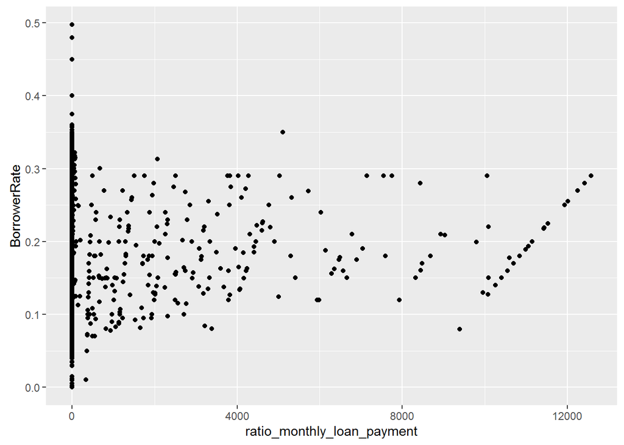

```r
ggplot(aes(x=ratio_monthly_loan_payment,y=BorrowerRate), data=df) +
  geom_point()
```

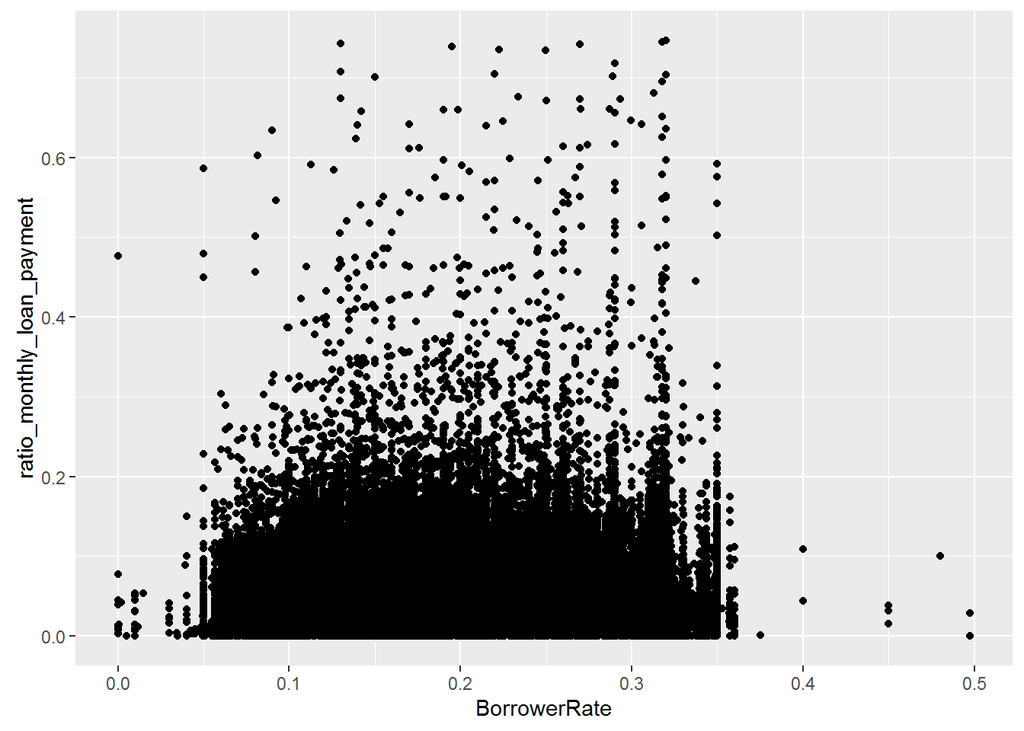

```r
ggplot(aes(y=ratio_monthly_loan_payment,x=BorrowerRate), data=subset(df,ratio_monthly_loan_payment<=.75)) +
  geom_point()
```

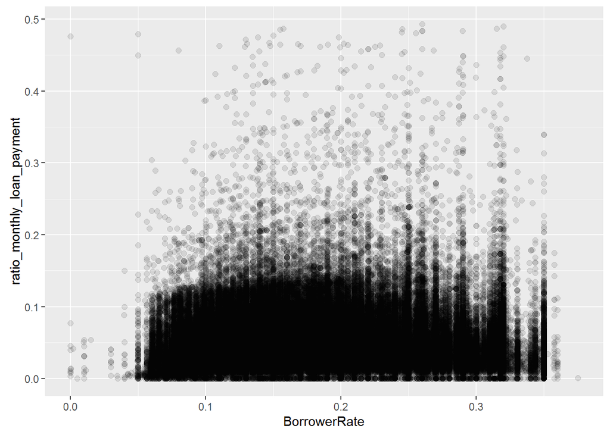

```r
ggplot(aes(y=ratio_monthly_loan_payment,x=BorrowerRate), data=subset(df,ratio_monthly_loan_payment<=.5 & BorrowerRate<.4)) +
  geom_jitter(alpha=.1, size=2)
```

Alpha is set to 0.1 and the data is subsetted to get a better graph.

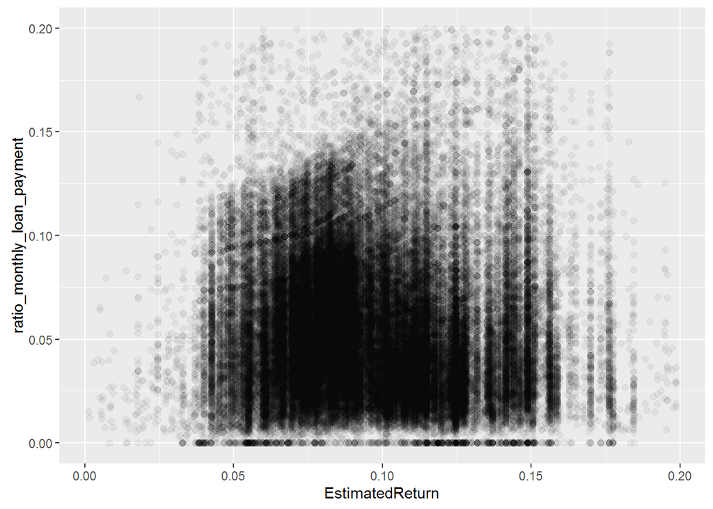

```r
ggplot(aes(y=ratio_monthly_loan_payment,x=EstimatedReturn), data=subset(df,ratio_monthly_loan_payment<=.2 & EstimatedReturn<0.2 & EstimatedReturn>0.0)) +
  geom_jitter(alpha=.05, size=2)
```

The graph between ratio monthly loan payment and EstimatedReturn variables shows no obvious pattern. Ratio tends to be slightly higher at 0.10 EstimatedReturn but the trend is way too subtle.

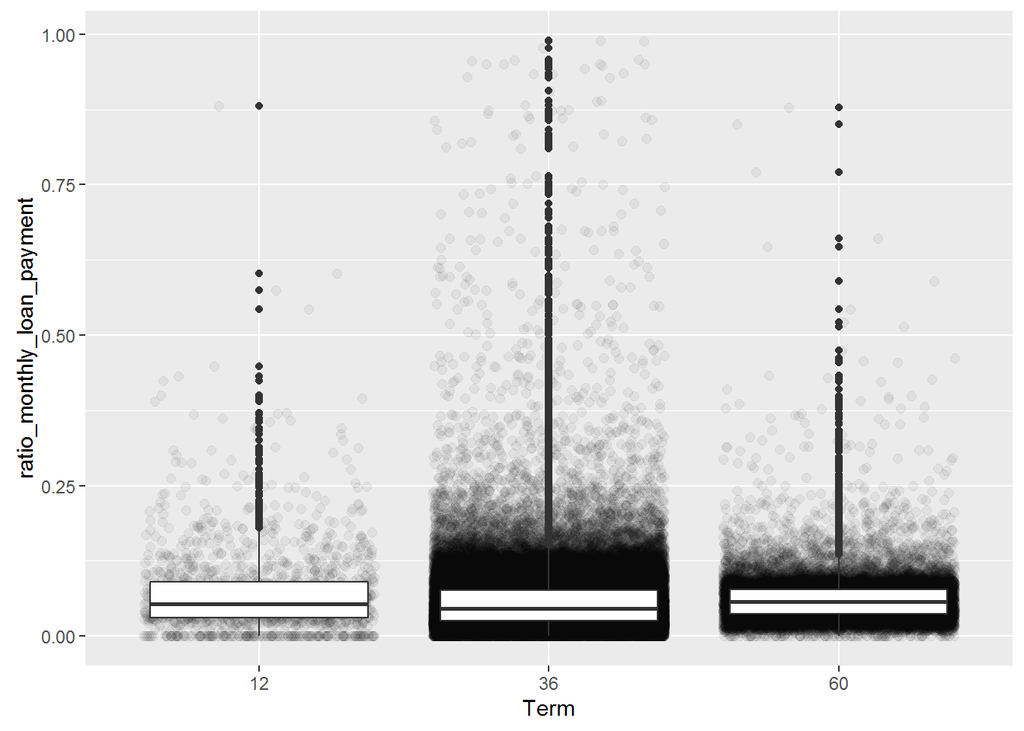

```r
ggplot(aes(y=ratio_monthly_loan_payment,x=Term), data=subset(df,ratio_monthly_loan_payment<=1)) +
  geom_jitter(alpha=.05, size=2) +
  geom_boxplot()
```

```r
by(df$ratio_monthly_loan_payment,df$Term, summary)
```

```
## df$Term: 12
##      Min.   1st Qu.    Median      Mean   3rd Qu.      Max.
##   0.00000   0.03044   0.05301   0.30700   0.09036 192.30000
## --------------------------------------------------------
## df$Term: 36
##      Min.   1st Qu.    Median      Mean   3rd Qu.      Max.
##     0.000     0.025     0.045    10.420     0.077 12570.000
## --------------------------------------------------------
## df$Term: 60
##     Min.  1st Qu.   Median     Mean  3rd Qu.     Max.
##   0.0000   0.0374   0.0566   0.1216   0.0768 662.6000
```

```r
df[,c(5,85)] %>%
  filter(ratio_monthly_loan_payment<=1) %>%
  group_by(Term) %>%
  dplyr::summarise(n=n())
```

```
## Source: local data frame [3 x 2]
##
##     Term     n
##   (fctr) (int)
## 1     12  1608
## 2     36 87387
## 3     60 24521
```

Although median is the largest when the Term is 60, the mean is the largest when the Term is 36.

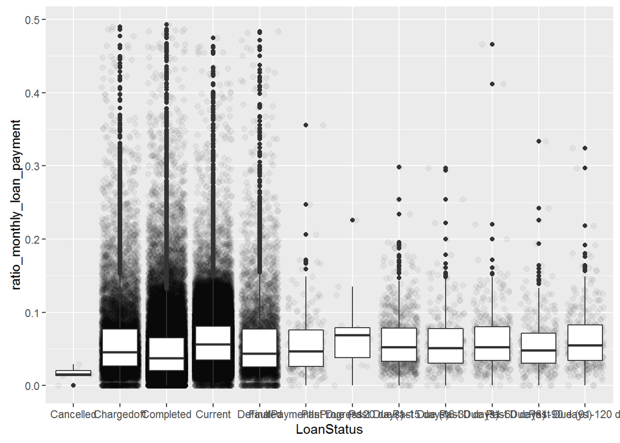

```r
ggplot(aes(y=ratio_monthly_loan_payment,x=LoanStatus), data=subset(df,ratio_monthly_loan_payment<=0.5)) +
  geom_jitter(alpha=.05, size=2) +
  geom_boxplot()
```

```r
by(df$ratio_monthly_loan_payment,df$LoanStatus, summary)
```

```
## df$LoanStatus: Cancelled
##    Min. 1st Qu.  Median    Mean 3rd Qu.    Max.
## 0.00000 0.01334 0.01504 0.01559 0.02049 0.02908
## --------------------------------------------------------
## df$LoanStatus: Chargedoff
##      Min.   1st Qu.    Median      Mean   3rd Qu.      Max.
##     0.000     0.027     0.046    28.450     0.079 12570.000
## --------------------------------------------------------
## df$LoanStatus: Completed
##      Min.   1st Qu.    Median      Mean   3rd Qu.      Max.
##     0.000     0.020     0.038    10.070     0.066 12250.000
## --------------------------------------------------------
## df$LoanStatus: Current
##     Min.  1st Qu.   Median     Mean  3rd Qu.     Max.
##   0.0000   0.0346   0.0561   0.1050   0.0807 662.6000
## --------------------------------------------------------
## df$LoanStatus: Defaulted
##      Min.   1st Qu.    Median      Mean   3rd Qu.      Max.
##     0.000     0.026     0.044    36.730     0.079 12250.000
## --------------------------------------------------------
## df$LoanStatus: FinalPaymentInProgress
##    Min. 1st Qu.  Median    Mean 3rd Qu.    Max.
## 0.00000 0.02599 0.04673 0.05682 0.07545 0.35570
## --------------------------------------------------------
## df$LoanStatus: Past Due (>120 days)
##    Min. 1st Qu.  Median    Mean 3rd Qu.    Max.
## 0.00000 0.03811 0.06871 0.07351 0.07901 0.22600
## --------------------------------------------------------
## df$LoanStatus: Past Due (1-15 days)
##    Min. 1st Qu.  Median    Mean 3rd Qu.    Max.
## 0.00000 0.03305 0.05222 0.06521 0.07848 2.08000
## --------------------------------------------------------
## df$LoanStatus: Past Due (16-30 days)
##     Min.  1st Qu.   Median     Mean  3rd Qu.     Max.
##   0.0000   0.0305   0.0511   2.6280   0.0785 679.8000
## --------------------------------------------------------
## df$LoanStatus: Past Due (31-60 days)
##      Min.   1st Qu.    Median      Mean   3rd Qu.      Max.
##    0.0000    0.0341    0.0532    5.7760    0.0802 2073.0000
## --------------------------------------------------------
## df$LoanStatus: Past Due (61-90 days)
##      Min.   1st Qu.    Median      Mean   3rd Qu.      Max.
##   0.00000   0.03046   0.04890   0.55540   0.07273 150.90000
## --------------------------------------------------------
## df$LoanStatus: Past Due (91-120 days)
##    Min. 1st Qu.  Median    Mean 3rd Qu.    Max.
## 0.00000 0.03458 0.05538 0.06728 0.08304 1.03700
```

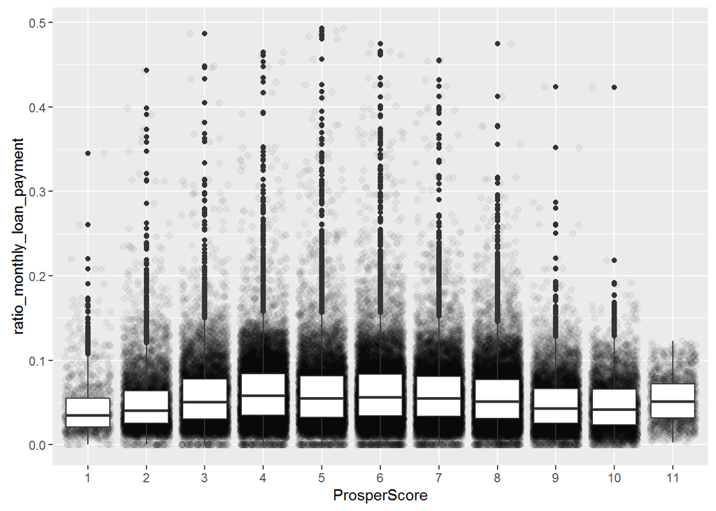

```r
ggplot(aes(y=ratio_monthly_loan_payment,x=ProsperScore), data=subset(df,ratio_monthly_loan_payment<=0.5 & !is.na(ProsperScore))) +
  geom_jitter(alpha=.05, size=2) +
  geom_boxplot()
```

```r
by(subset(df,ratio_monthly_loan_payment<=0.5 & !is.na(ProsperScore))$ratio_monthly_loan_payment, subset(df,ratio_monthly_loan_payment<=0.5 & !is.na(ProsperScore))$ProsperScore, summary)
```

```
## subset(df, ratio_monthly_loan_payment <= 0.5 & !is.na(ProsperScore))$ProsperScore: 1
##    Min. 1st Qu.  Median    Mean 3rd Qu.    Max.
## 0.00000 0.02088 0.03460 0.04419 0.05513 0.34490
## --------------------------------------------------------
## subset(df, ratio_monthly_loan_payment <= 0.5 & !is.na(ProsperScore))$ProsperScore: 2
##    Min. 1st Qu.  Median    Mean 3rd Qu.    Max.
## 0.00000 0.02549 0.04036 0.04934 0.06350 0.44350
## --------------------------------------------------------
## subset(df, ratio_monthly_loan_payment <= 0.5 & !is.na(ProsperScore))$ProsperScore: 3
##    Min. 1st Qu.  Median    Mean 3rd Qu.    Max.
## 0.00000 0.03029 0.05062 0.05840 0.07790 0.48680
## --------------------------------------------------------
## subset(df, ratio_monthly_loan_payment <= 0.5 & !is.na(ProsperScore))$ProsperScore: 4
##    Min. 1st Qu.  Median    Mean 3rd Qu.    Max.
## 0.00000 0.03484 0.05790 0.06302 0.08399 0.46500
## --------------------------------------------------------
## subset(df, ratio_monthly_loan_payment <= 0.5 & !is.na(ProsperScore))$ProsperScore: 5
##    Min. 1st Qu.  Median    Mean 3rd Qu.    Max.
## 0.00000 0.03231 0.05468 0.06244 0.08163 0.49300
## --------------------------------------------------------
## subset(df, ratio_monthly_loan_payment <= 0.5 & !is.na(ProsperScore))$ProsperScore: 6
##    Min. 1st Qu.  Median    Mean 3rd Qu.    Max.
## 0.00000 0.03390 0.05604 0.06336 0.08301 0.47510
## --------------------------------------------------------
## subset(df, ratio_monthly_loan_payment <= 0.5 & !is.na(ProsperScore))$ProsperScore: 7
##    Min. 1st Qu.  Median    Mean 3rd Qu.    Max.
## 0.00000 0.03322 0.05505 0.06098 0.08076 0.45510
## --------------------------------------------------------
## subset(df, ratio_monthly_loan_payment <= 0.5 & !is.na(ProsperScore))$ProsperScore: 8
##    Min. 1st Qu.  Median    Mean 3rd Qu.    Max.
## 0.00000 0.03074 0.05130 0.05757 0.07677 0.47470
## --------------------------------------------------------
## subset(df, ratio_monthly_loan_payment <= 0.5 & !is.na(ProsperScore))$ProsperScore: 9
##    Min. 1st Qu.  Median    Mean 3rd Qu.    Max.
## 0.00000 0.02521 0.04286 0.04827 0.06629 0.42360
## --------------------------------------------------------
## subset(df, ratio_monthly_loan_payment <= 0.5 & !is.na(ProsperScore))$ProsperScore: 10
##    Min. 1st Qu.  Median    Mean 3rd Qu.    Max.
## 0.00000 0.02329 0.04147 0.04665 0.06552 0.42300
## --------------------------------------------------------
## subset(df, ratio_monthly_loan_payment <= 0.5 & !is.na(ProsperScore))$ProsperScore: 11
##     Min.  1st Qu.   Median     Mean  3rd Qu.     Max.
## 0.002689 0.031750 0.051300 0.053250 0.072210 0.122800
```

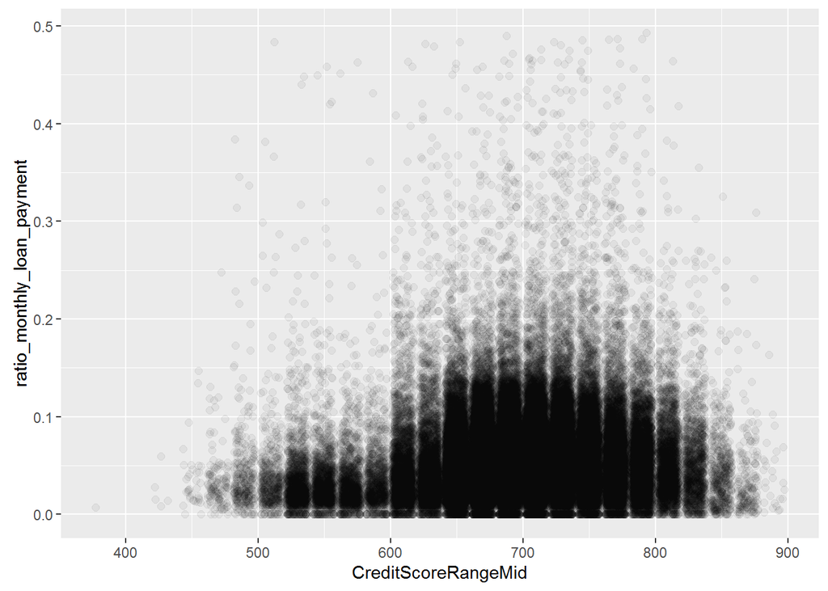

```r
ggplot(aes(y=ratio_monthly_loan_payment,x=CreditScoreRangeMid),
       data=subset(df,ratio_monthly_loan_payment<=0.5 &
                     !is.na(CreditScoreRangeMid) &
                     CreditScoreRangeMid > 300)) +
  geom_jitter(alpha=.05, size=2)
```

People with good credit score tend to have a higher ratio.

# Bivariate Analysis

### Talk about some of the relationships you observed in this part of the investigation. How did the feature(s) of interest vary with other features in the dataset?

### Did you observe any interesting relationships between the other features (not the main feature(s) of interest)?

### What was the strongest relationship you found?

# Multivariate Plots Section

# Multivariate Analysis

### Talk about some of the relationships you observed in this part of the investigation. Were there features that strengthened each other in terms of looking at your feature(s) of interest?

### Were there any interesting or surprising interactions between features?

### OPTIONAL: Did you create any models with your dataset? Discuss the strengths and limitations of your model.

# Final Plots and Summary

### Plot One

### Description One

### Plot Two

### Description Two

### Plot Three

### Description Three

# Reflection